# Evening Affect ~ Close Out-Degree * Interaction Medium (Online)

Ovidia Stanoi

2025-02-26

### Prepare data for regression analyses.

Remove all data from the global environment.

```r
remove(list=ls())
```

Load libraries.

```r
library("tidyverse")
library("rstanarm")
library("sjPlot")
library("brms")
library("bmlm")
```

Define directory path.

```r
path <- "~/Dropbox/Psychology_Projects/Close Relations, Affect & Stress During the COVID19 Pandemic"
```

Open dataset.

```r
covid_ema <- read.csv(sprintf("%s/Data/all_data_merged_clean.csv", path))
```

Center the continuous predictors that represent between-individual differences around the sample mean; center binary variables around zero.

```r
# Extract for each participant their close out-degree, demographic information, and COVID-19 information
df <- covid_ema %>%
  group_by(pID) %>%
  dplyr::summarise(baseline_closest_deg_out_norm = unique(baseline_closest_deg_out_norm),
                   baseline_income_num = unique(baseline_income_num),
                   baseline_educ_parents_years = unique(baseline_educ_parents_years),
                   baseline_college_year = unique(baseline_college_year),
                   baseline_gender_numeric = unique(baseline_gender_numeric),
                   covid_housing_tension = unique(covid_housing_tension),
                   covid_phys_dist = unique(covid_phys_dist_avg))

# Center variables around the mean
df$baseline_closest_deg_out_norm_c <- df$baseline_closest_deg_out_norm - mean(df$baseline_closest_deg_out_norm, na.rm = T)
df$baseline_income_num_c <- df$baseline_income_num - mean(df$baseline_income_num, na.rm = T)
df$baseline_educ_parents_years_c <- df$baseline_educ_parents_years - mean(df$baseline_educ_parents_years, na.rm = T)
df$baseline_college_year_c <- df$baseline_college_year - mean(df$baseline_college_year, na.rm = T)
df$baseline_gender_numeric_c <- df$baseline_gender_numeric - .5
df$covid_housing_tension_c <- df$covid_housing_tension - mean(df$covid_housing_tension, na.rm = T)
df$covid_phys_dist_c  <- df$covid_phys_dist - mean(df$covid_phys_dist, na.rm = T)

# Add centered variables to the EMA dataset
covid_ema <- merge(covid_ema, df)
```

Separate the predictor(s) that vary both between- and within-individual in their within and between components. In our models, only the variable representing the medium of the most important interaction of the day (1 = online; 0 = in-person) varies both between- and within-individuals.

```r
covid_ema <- isolate(d = covid_ema, by = "pID",
                     value = c("SalInt_Medium_Online"),
                     which = "both")
```

### Run multilevel regression models

##### Model 1: Outcome Variable = Negative Affect

**RQ**: Do students with close friends in college have better quality online interactions (e.g., do they feel less negative affect at the end of the day when their most important social interaction was online as opposed to in-person)?

Run regression analysis 1: negative affect ~ close out-degree * medium of the interaction (within component).

```r
options(mc.cores = parallel::detectCores())
f <- stan_glmer(NegativeMood ~ baseline_closest_deg_out_norm_c * SalInt_Medium_Online_cw +
                  baseline_income_num_c + baseline_educ_parents_years_c + baseline_college_year_c +
                  baseline_gender_numeric_c + covid_housing_tension_c + covid_phys_dist_c + (1 | groupID:pID),
                data = covid_ema, seed = 123)
save(f, file = sprintf("%s/Models/2.b. Evening-NegAff_Out-Degree_Online-Interaction.RData", path))
```

##### Model 2: Outcome Variable = Positive Affect

**RQ**: Do students with close friends in college have better quality online interactions (e.g., do they feel more positive affect at the end of the day when their most important social interaction was online as opposed to in-person)?

Run regression analysis 2: positive affect ~ close out-degree * medium of the interaction (within component).

```r
options(mc.cores = parallel::detectCores())
fb <- stan_glmer(PositiveMood ~ baseline_closest_deg_out_norm_c * SalInt_Medium_Online_cw +
                  baseline_income_num_c + baseline_educ_parents_years_c + baseline_college_year_c +
                  baseline_gender_numeric_c + covid_housing_tension_c + covid_phys_dist_c + (1 | groupID:pID),
                data = covid_ema, seed = 123)
save(f, file = sprintf("%s/Models/2.b. Evening-PosAff_Out-Degree_Online-Interaction.RData", path))
```

### Summarize results

Create a table that presents the parameter estimates from the two models together.

```r
tab_model(f, fb, show.se = TRUE,
          show.r2 = TRUE,
          dv.labels = c("Evening Negative Affect",
                        "Evening Positive Affect"),
          pred.labels = c("(Intercept)",
                          "Close Out-Degree Prior to COVID19",
                          "Online Conversation (WI)",
                          "HH Income",
                          "Parents' Education",
                          "Year in College",
                          "Female",
                          "HH Tension",
                          "Physical Distance",
                          "Out-Degree * Online Conversation (WI) Interaction"),
          file = sprintf("%s/Tables/2.b. Evening-NegAff-PosAff-Out-Degree_Online_Interaction.html", path))
```

|  | Evening Negative Affect |  |  | Evening Positive Affect |  |  |
| --- | --- | --- | --- | --- | --- | --- |
| Predictors | Estimates | std. Error | CI (95%) | Estimates | std. Error | CI (95%) |
| (Intercept) | 29.52 | 1.04 | 27.52 – 31.51 | 64.26 | 1.10 | 62.10 – 66.33 |
| Close Out-Degree Prior to COVID19 | -0.23 | 0.09 | -0.43 – -0.05 | 0.22 | 0.10 | 0.03 – 0.42 |
| Online Conversation (WI) | 2.40 | 0.73 | 1.03 – 3.80 | -3.04 | 0.68 | -4.38 – -1.63 |
| HH Income | 0.09 | 0.17 | -0.25 – 0.43 | -0.08 | 0.18 | -0.46 – 0.30 |
| Parents’ Education | -0.25 | 0.25 | -0.71 – 0.21 | 0.15 | 0.26 | -0.34 – 0.64 |
| Year in College | -1.31 | 0.78 | -2.88 – 0.21 | 1.11 | 0.84 | -0.51 – 2.77 |
| Female | -0.23 | 2.20 | -4.56 – 4.01 | -1.14 | 2.28 | -5.75 – 3.08 |
| HH Tension | 0.11 | 0.03 | 0.04 – 0.18 | -0.09 | 0.04 | -0.17 – -0.02 |
| Physical Distance | -0.47 | 1.22 | -2.95 – 1.95 | -0.21 | 1.34 | -2.69 – 2.42 |
| Out-Degree * Online Conversation (WI) Interaction | -0.16 | 0.08 | -0.32 – -0.01 | 0.15 | 0.08 | 0.00 – 0.30 |
| Random Effects |  |  |  |  |  |  |
| σ<sup>2</sup> | 328.53 |  |  | 312.17 |  |  |
| τ<sub>00</sub> | 147.40 <sub>groupID:pID</sub> |  |  | 165.25 <sub>groupID:pID</sub> |  |  |
| ICC | 0.31 |  |  | 0.35 |  |  |
| N | 24 <sub>groupID</sub> |  |  | 24 <sub>groupID</sub> |  |  |
|  | 205 <sub>pID</sub> |  |  | 205 <sub>pID</sub> |  |  |
| Observations | 4371 |  |  | 4369 |  |  |
| Marginal R<sup>2</sup> / Conditional R<sup>2</sup> | 0.036 / 0.334 |  |  | 0.030 / 0.366 |  |  |

Below, extract the proportion of the posterior distribution that is above or below zero for each predictor of interest separately for the two regression models (evening negative and positive affect).

##### Model 1: Outcome Variable = Negative Affect

Extract the posterior distributions of the parameters from the first regression model.

```r
posterior <- as.data.frame(as.matrix(f))
```

Extract the number of individual points included in a posterior distribution.

```r
n <- length(posterior$baseline_closest_deg_out_norm_c)
n
```

```
## [1] 4000
```

Calculate the proportion of the posterior distribution that is lower than 0 for the main effect of close out-degree on evening negative affect.

```r
round(length(which(posterior$baseline_closest_deg_out_norm_c < 0))/n*100,1)
```

```
## [1] 99.4
```

Calculate the proportion of the posterior distribution that is higher than 0 for the main effect of online interactions on evening negative affect.

```r
round(length(which(posterior$SalInt_Medium_Online_cw > 0))/n*100,1)
```

```
## [1] 100
```

Calculate the proportion of the posterior distribution that is lower than 0 for the interaction effect between participants’ close out-degree and online interactions on evening negative affect.

```r
round(length(which(posterior$`baseline_closest_deg_out_norm_c:SalInt_Medium_Online_cw` < 0))/n*100,1)
```

```
## [1] 98
```

Calculate the total $R^2$ for the model.

```r
round(mean(bayes_R2(f)),2)
```

```
## [1] 0.34
```

##### Model 2: Outcome Variable = Positive Affect

Extract the posterior distributions of the parameters from the second regression model.

```r
posterior <- as.data.frame(as.matrix(fb))
```

Extract the number of individual points included in a posterior distribution.

```r
n <- length(posterior$baseline_closest_deg_out_norm_c)
n
```

```
## [1] 4000
```

```r
round(length(which(posterior$baseline_closest_deg_out_norm_c > 0))/n*100,1)
```

```
## [1] 98.7
```

```r
round(length(which(posterior$SalInt_Medium_Online_cw < 0))/n*100,1)
```

```
## [1] 100
```

```r
round(length(which(posterior$`baseline_closest_deg_out_norm_c:SalInt_Medium_Online_cw` > 0))/n*100,1)
```

```
## [1] 97.8
```

Calculate the total $R^2$ for the model.

```r
round(mean(bayes_R2(fb)),2)
```

```
## [1] 0.35
```

### General Linear Hypothesis Tests (GLHT)

##### Model 1: Outcome Variable = Negative Affect

Test the hypothesis: does the slope representing the relationship between online interactions and evening negative affect differ from zero for 1) students with few friends at school (1.5 SD below mean), 2) students with many friends at school (1.5 SD above mean)?

```r
# Calculate mean close out-degree  +/-1.5SD
lw_1.5sd <- round(-1.5*sd(df$baseline_closest_deg_out_norm_c, na.rm = T),3)
lw_1.5sd
```

```
## [1] -14.884
```

```r
up_1.5sd <- round(+1.5*sd(df$baseline_closest_deg_out_norm_c, na.rm = T),3)
up_1.5sd
```

```
## [1] 14.884
```

```r
# Define the number of draws from the posterior distribution
n <- 4000
```

Test the hypothesis for those with few close friends first.

```r
my_hyp_lw <- hypothesis(f, "1*SalInt_Medium_Online_cw +
                      -14.884*baseline_closest_deg_out_norm_c:SalInt_Medium_Online_cw = 0")
p <- my_hyp_lw$samples
df_hyp <- my_hyp_lw$hypothesis[ ,2:5] %>%
  mutate(Prop.Above.Zero = length(which(p$H1 > 0))/n) %>%
  mutate_if(is.numeric, funs(round(., digits = 2)))
df_hyp
```

```
##   Estimate Est.Error CI.Lower CI.Upper Prop.Above.Zero
## 1     4.83      1.33     2.27     7.47               1
```

Test the hypothesis for those with many close friends.

```r
my_hyp_up <- hypothesis(f, "1*SalInt_Medium_Online_cw +
                      14.884*baseline_closest_deg_out_norm_c:SalInt_Medium_Online_cw = 0")
p <- my_hyp_up$samples
df_hyp <- my_hyp_up$hypothesis[ ,2:5] %>%
  mutate(Prop.Above.Zero = length(which(p$H1 > 0))/n) %>%
  mutate_if(is.numeric, funs(round(., digits = 2)))
df_hyp
```

```
##   Estimate Est.Error CI.Lower CI.Upper Prop.Above.Zero
## 1    -0.03      1.38    -2.66     2.64             0.5
```

##### Model 2: Outcome Variable = Positive Affect

Test the hypothesis: does the slope representing the relationship between online interactions and evening positive affect differ from zero for 1) students with few friends at school (1.5 SD below mean), 2) students with many friends at school (1.5 SD above mean)?

Test the hypothesis for those with few close friends first.

```r
# Define the number of draws from the posterior distribution
n <- 4000

my_hyp_lw <- hypothesis(fb, "1*SalInt_Medium_Online_cw +
                      -14.884*baseline_closest_deg_out_norm_c:SalInt_Medium_Online_cw = 0")
p <- my_hyp_lw$samples
df_hyp <- my_hyp_lw$hypothesis[ ,2:5] %>%
  mutate(Prop.Below.Zero = length(which(p$H1 < 0))/n) %>%
  mutate_if(is.numeric, funs(round(., digits = 2)))
df_hyp
```

```
##   Estimate Est.Error CI.Lower CI.Upper Prop.Below.Zero
## 1     -5.3      1.28    -7.79    -2.79               1
```

Test hypothesis for those with many close friends next.

```r
my_hyp_up <- hypothesis(fb, "1*SalInt_Medium_Online_cw +
                      14.884*baseline_closest_deg_out_norm_c:SalInt_Medium_Online_cw = 0")
p <- my_hyp_up$samples
df_hyp <- my_hyp_up$hypothesis[ ,2:5] %>%
  mutate(Prop.Below.Zero = length(which(p$H1 < 0))/n) %>%
  mutate_if(is.numeric, funs(round(., digits = 2)))
df_hyp
```

```
##   Estimate Est.Error CI.Lower CI.Upper Prop.Below.Zero
## 1    -0.78      1.36    -3.39     1.89            0.71
```

### Plot results

##### Model 1: Outcome Variable = Negative Affect

Create a scatterplot showing the relationship between the interaction type (online versus in persons) and evening negative affect for people with few (1.5 SD below mean) or many (1.5 SD above mean) close friends in college.

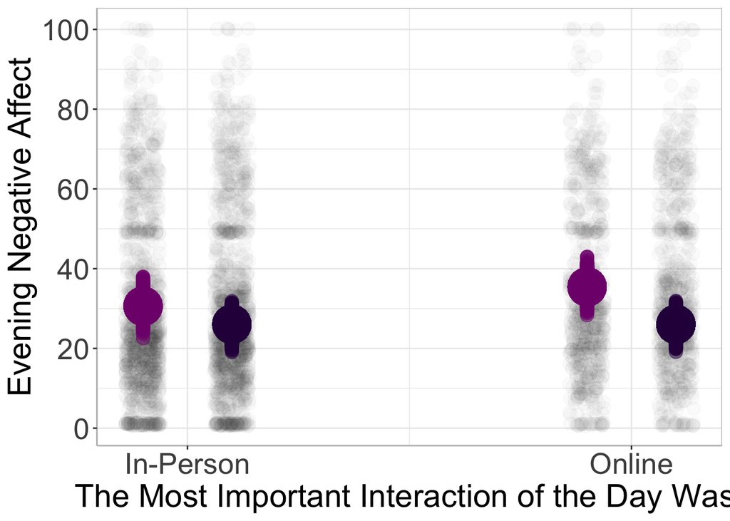

```r
# Extract all posterior distributions
p <- posterior_samples(f)[, c(1:3,10)]
colnames(p) <- c("intercept", "b_close_deg_out", "b_online", "b_online_close_deg_out_int")

# Define the number of random draws
n <- 4000

# Extract fixed effects medians from the model
p <- p %>%
  dplyr::mutate(draw = 1:n,
                m_int = median(intercept),
                m_b_online = median(b_online),
                m_b_close_deg_out = median(b_close_deg_out),
                m_b_online_close_deg_out_int = median(b_online_close_deg_out_int))

# Create a dataframe that includes predicted y values for each draw for students without a lot of friends
p_lw <- p[rep(seq_len(nrow(p)), each = 2), ] %>%
  dplyr::mutate(seq = rep(c(-.5,.5), n),
                close_deg_out = lw_1.5sd,
                close_deg_out_label = "Low (-1.5 SD)") %>%
  rowwise() %>%
  dplyr::mutate(y_draw = intercept + b_online * seq + b_close_deg_out * close_deg_out +
                  b_online_close_deg_out_int * close_deg_out * seq,
                y_fe = m_int + m_b_online * seq + m_b_close_deg_out * close_deg_out +
                  m_b_online_close_deg_out_int * close_deg_out * seq)

# Create a dataframe that includes predicted y values for each draw for students with a lot of friends
p_up <- p[rep(seq_len(nrow(p)), each = 2), ] %>%
  mutate(seq = rep(c(-.5,.5), n),
         close_deg_out = up_1.5sd,
         close_deg_out_label = "High (+ 1.5 SD)") %>%
  rowwise() %>%
  dplyr::mutate(y_draw = intercept + b_online * seq + b_close_deg_out * close_deg_out +
                  b_online_close_deg_out_int * close_deg_out * seq,
                y_fe = m_int + m_b_online * seq + m_b_close_deg_out * close_deg_out +
                  m_b_online_close_deg_out_int * close_deg_out * seq)

# Merge files
p_all <- rbind(p_lw, p_up)

# Make the grouping variable a factor
p_all$close_deg_out_label <- factor(p_all$close_deg_out_label,
                                    levels = c("Low (-1.5 SD)",
                                               "High (+ 1.5 SD)"))

# Stagger position on the x-axis
p_up$seq2 <- ifelse(p_up$seq == -.5, -0.3,
                    ifelse(p_up$seq == .5, .7, NA))

# Separate the covid_ema dataset in two subsets:
# one including the data of the people without a lot of friends
covid_ema_lw <- covid_ema[covid_ema$baseline_closest_deg_out_norm_c < median(covid_ema$baseline_closest_deg_out_norm_c, na.rm = T),]
covid_ema_lw$SalInt_Medium_Online_2 <- ifelse(covid_ema_lw$SalInt_Medium_Online == 1, .5,
                                              ifelse(covid_ema_lw$SalInt_Medium_Online == 0, -.5, NA))

# Separate the covid_ema dataset in two subsets:
# one including the data of the people with a lot of friends
covid_ema_up <- covid_ema[covid_ema$baseline_closest_deg_out_norm_c < median(covid_ema$baseline_closest_deg_out_norm_c, na.rm = T),]
covid_ema_up$SalInt_Medium_Online_2 <- ifelse(covid_ema_up$SalInt_Medium_Online == 1, .7,
                                              ifelse(covid_ema_up$SalInt_Medium_Online == 0, -.3, NA))

# Plot results -- together
ggplot() +
  geom_jitter(data = covid_ema_lw, aes(x = SalInt_Medium_Online_2,
                                      y = NegativeMood),
              width = .04, alpha = .02, size = 4) +
  geom_jitter(data = covid_ema_up, aes(x = SalInt_Medium_Online_2,
                                       y = NegativeMood),
              width = .04, alpha = .02, size = 4) +
  geom_point(data = p_lw, aes(x = seq, y= y_draw,
                              group = draw),
             color = "#810F7C", alpha = .5, size = 4) +
  geom_point(data = p_lw, aes(x = seq, y = y_fe),
             color = "#810F7C", size = 12) +
  geom_point(data = p_up, aes(x = seq2, y= y_draw,
                              group = draw),
             color = "#2D004B", alpha = .5, size = 4) +
  geom_point(data = p_up, aes(x = seq2,
                              y = y_fe),
             color = "#2D004B", size = 12) +
  labs(y = "Evening Negative Affect",
       x = "The Most Important Interaction of the Day Was:") +
  scale_y_continuous(breaks = c(0,20,40,60,80,100)) +
  scale_x_continuous(breaks = c(-.4, .6),
                     labels = c("In-Person", "Online")) +
  theme_bw() +
  theme(axis.text=element_text(size=20),
        axis.title=element_text(size=22),
        axis.line = element_line(colour = "gray"),
        panel.border = element_rect(colour = "gray"),
        strip.text = element_text(size=16))
```

```r
ggsave(file=sprintf("%s/Figures/2.b. Evening-NegAff_Out-Degree_Online-Interaction.pdf",path),
       units="in", width=8, height=6, dpi=300)
```

##### Model 2: Outcome Variable = Positive Affect

Create a scatterplot showing the relationship between the interaction type (online versus in persons) and evening positive affect for people with few (1.5 SD below mean) or many (1.5 SD above mean) close friends in college.

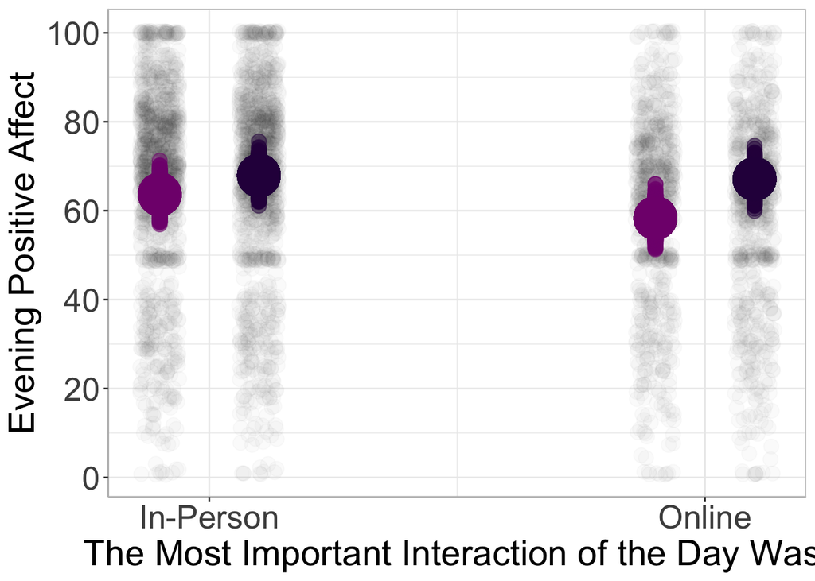

```r
# Extract all posterior distributions
p <- posterior_samples(fb)[, c(1:3, 10)]
colnames(p) <- c("intercept", "b_close_deg_out", "b_online", "b_online_close_deg_out_int")

# Define the number of random draws
n <- 4000

# Extract fixed effects medians from the model
p <- p %>%
  dplyr::mutate(draw = 1:n,
                m_int = median(intercept),
                m_b_online = median(b_online),
                m_b_close_deg_out = median(b_close_deg_out),
                m_b_online_close_deg_out_int = median(b_online_close_deg_out_int))

# Create a dataframe that includes predicted y values for each draw for students without a lot of friends
p_lw <- p[rep(seq_len(nrow(p)), each = 2), ] %>%
  dplyr::mutate(seq = rep(c(-.5,.5), n),
                close_deg_out = lw_1.5sd,
                close_deg_out_label = "Low (-1.5 SD)") %>%
  rowwise() %>%
  dplyr::mutate(y_draw = intercept + b_online * seq + b_close_deg_out * close_deg_out +
                  b_online_close_deg_out_int * close_deg_out * seq,
                y_fe = m_int + m_b_online * seq + m_b_close_deg_out * close_deg_out +
                  m_b_online_close_deg_out_int * close_deg_out * seq)

# Create a dataframe that includes predicted y values for each draw for students with a lot of friends
p_up <- p[rep(seq_len(nrow(p)), each = 2), ] %>%
  mutate(seq = rep(c(-.5,.5), n),
         close_deg_out = up_1.5sd,
         close_deg_out_label = "High (+ 1.5 SD)") %>%
  rowwise() %>%
  dplyr::mutate(y_draw = intercept + b_online * seq + b_close_deg_out * close_deg_out +
                  b_online_close_deg_out_int * close_deg_out * seq,
                y_fe = m_int + m_b_online * seq + m_b_close_deg_out * close_deg_out +
                  m_b_online_close_deg_out_int * close_deg_out * seq)

# Merge files
p_all <- rbind(p_lw, p_up)

# Make the grouping variable a factor
p_all$close_deg_out_label <- factor(p_all$close_deg_out_label,
                                    levels = c("Low (-1.5 SD)",
                                               "High (+ 1.5 SD)"))

# Plot results -- together
p_up$seq2 <- ifelse(p_up$seq == -.5, -0.3,
                    ifelse(p_up$seq == .5, .7, NA))
ggplot() +
  geom_jitter(data = covid_ema_lw, aes(x = SalInt_Medium_Online_2,
                                       y = PositiveMood),
              width = .04, alpha = .02, size = 4) +
  geom_jitter(data = covid_ema_up, aes(x = SalInt_Medium_Online_2,
                                       y = PositiveMood),
              width = .04, alpha = .02, size = 4) +
  geom_point(data = p_lw, aes(x = seq, y= y_draw,
                              group = draw),
             color = "#810F7C", alpha = .5, size = 4) +
  geom_point(data = p_lw, aes(x = seq, y = y_fe),
             color = "#810F7C", size = 12) +
  geom_point(data = p_up, aes(x = seq2, y= y_draw,
                              group = draw),
             color = "#2D004B", alpha = .5, size = 4) +
  geom_point(data = p_up, aes(x = seq2,
                              y = y_fe),
             color = "#2D004B", size = 12) +
  labs(y = "Evening Positive Affect",
       x = "The Most Important Interaction of the Day Was:") +
  scale_y_continuous(breaks = c(0,20,40,60,80,100)) +
  scale_x_continuous(breaks = c(-.4, .6),
                     labels = c("In-Person", "Online")) +
  theme_bw() +
  theme(axis.text=element_text(size=20),
        axis.title=element_text(size=22),
        axis.line = element_line(colour = "gray"),
        panel.border = element_rect(colour = "gray"),
        strip.text = element_text(size=16))
```

```r
ggsave(file=sprintf("%s/Figures/2.b. Evening-PosAff_Out-Degree_Online-Interaction.pdf",path),
       units="in", width=8, height=6, dpi=300)
```